# Part 2: Data Analysis

Timothy Nsubuga

12/13/2021

# Directions and Questions

You’ll perform a complete data analysis on the Delomys species data. You can do your work in a RMarkdown document, or an R script.

```r
require(here)
delomys = read.csv(here("data","delomys.csv"))
```

## Data Exploration

#### Numerical Exploration

Create a code chunk that includes the following:

Use summary() on the body mass and body length data columns in the Delomys data set to display summary statistics.

```r
summary(delomys$body_mass)
```

```
##    Min. 1st Qu.  Median    Mean 3rd Qu.    Max.
##    5.00   35.00   43.00   44.06   54.00  105.00
```

```r
summary(delomys$body_length)
```

```
##    Min. 1st Qu.  Median    Mean 3rd Qu.    Max.
##    49.0   106.0   116.0   114.7   124.0   265.0
```

Perform a test of normality on the body mass and length columns. You can use shapiro.test()

```r
shapiro.test(delomys$body_mass)
```

```
##
##  Shapiro-Wilk normality test
##
## data:  delomys$body_mass
## W = 0.99506, p-value = 4.33e-05
```

```r
shapiro.test(delomys$body_length)
```

```
##
##  Shapiro-Wilk normality test
##
## data:  delomys$body_length
## W = 0.87609, p-value < 2.2e-16
```

### Graphical Exploration

You can adjust the size of the plots on your rendered document using the following code chunk arguments:

fig.height= fig.width=

You can adjust the aspect ratio using fig.aspect=

The code chunk format with an option looks like:

The code chunk format with an option looks like:

```r
require(palmerpenguins)
```

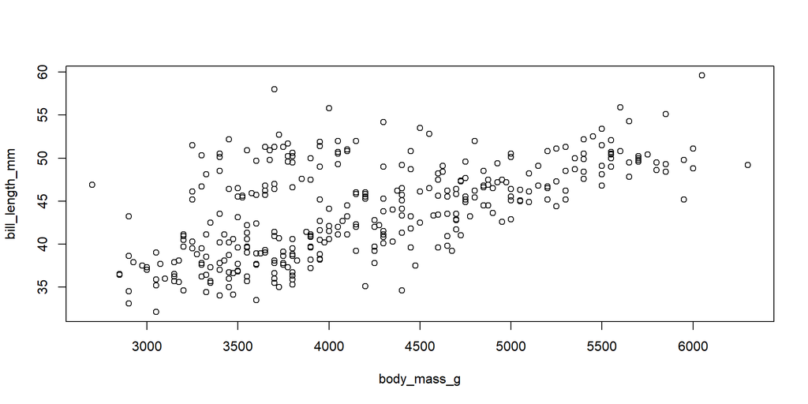

```r
plot(bill_length_mm ~ body_mass_g, data = penguins)
```

Using code chunks, create the following plots, which you’ll use to answer the report questions:

A scatterplot of body mass and body length

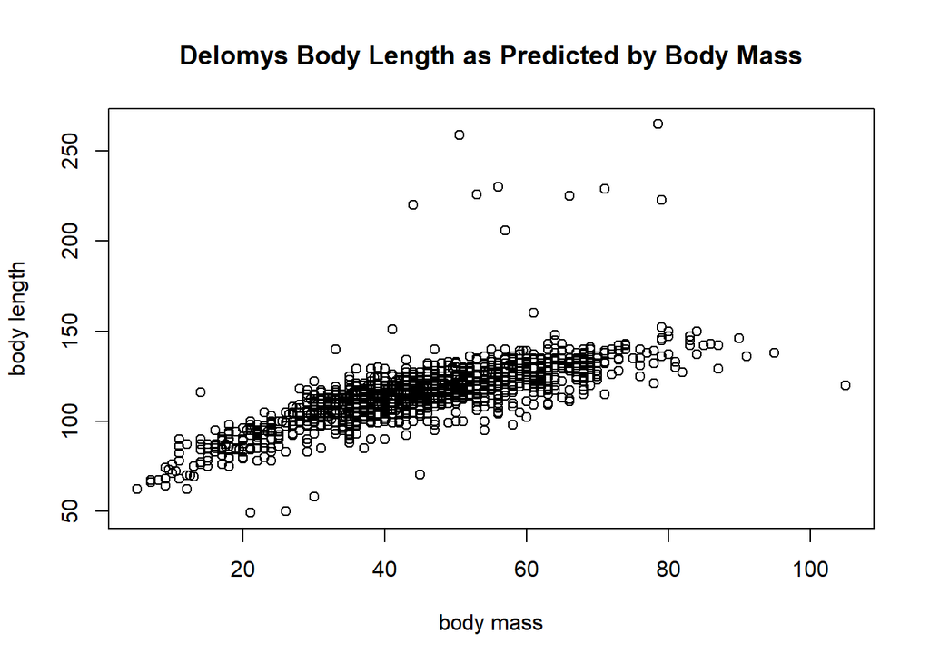

```r
plot(delomys$body_mass, delomys$body_length, main = "Delomys Body Length as Predicted by Body Mass", xlab = "body mass", ylab = "body length")
```

A histogram of body mass

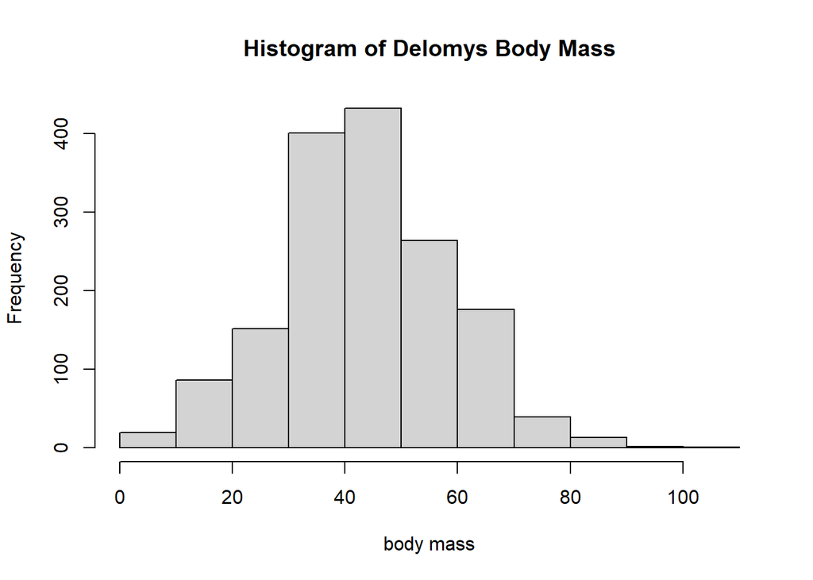

```r
hist(delomys$body_mass,  main = "Histogram of Delomys Body Mass", xlab = "body mass")
```

A histogram of body length

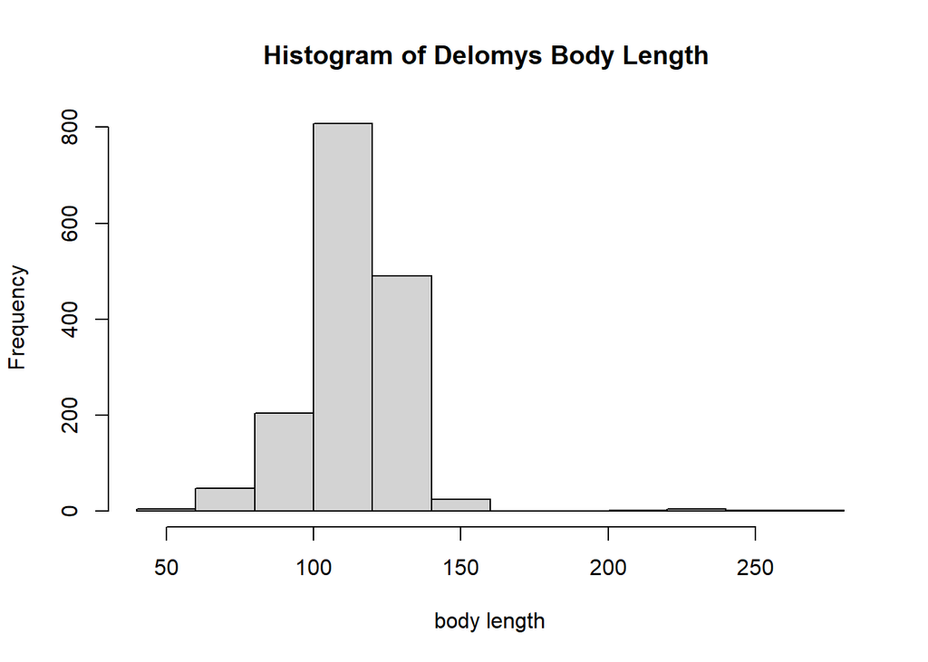

```r
hist(delomys$body_length, main = "Histogram of Delomys Body Length ", xlab = "body length")
```

A conditional boxplot of body mass, conditioned on species (column binomial)

[figure not shown]

```r
boxplot(formula = body_mass ~ binomial,
        main = " Delomys Body Length Conditioned on Species ",
        data = delomys)
```

A conditional boxplot of body mass, conditioned on sex

[figure not shown]

```r
boxplot(formula = body_mass ~ sex,
        main = " Delomys Body Length Conditioned on Sex",
        data = delomys)
```

A conditional boxplot of body mass, conditioned on both species and sex

[figure not shown]

```r
boxplot(formula = body_mass ~ binomial * sex,
        main = " Delomys Body Length Conditioned on Species and Sex",
        data = delomys,
       names = c("female\nDelomys\ndorsalis", "male\nDelomys\ndorsalis",

                 "female\nDelomys\nsublineatus", "male\nDelomys\nsublineatus")
)
```

## Q1-4

Answer the following in your report:

Q1 (2 pts.): Qualitatively describe the relationship between body mass and length.

Does the relationship seem linear, curved, nonexistent?

**There seems to be a positive linear relationship between body mass and length with outliers above and below this trend.**

Q2 (2 pts.): Qualitatively describe the shapes of the histograms. Do the data appear normally-distributed? Explain why or why not.

**No. The histogram of Delomys body mass is not symmetric since there are more body masses in the range of 40 to 80 than 0 to 40, in addition to body masses greater than 80.The histogram of Delomys body length appears to be right skewed.**

Q3 (3 pts.): Using both the histograms and normality tests, do you think the (unconditioned) body masses and body length are normally-distributed? Contrast your visual assessment of normality to the results of the numerical normality tests.

**No, the (unconditioned) body masses and body length are not normally-distributed because the Shapiro tests yield p -values of 4.33e-05 and 2.2e-16 ,respectively, which means we can reject the null hypothesis that the body masses and body length were sampled from a normally-distributed population.**

Q4 (2 pts.): Examine the conditional boxplots. Describe any graphical evidence you see for body mass differences based on species and/or sex.

## Model Building

We know that the normality assumption applies to the residual values after we fit a model.

Using a code chunk, fit 5 models using lm():

Model 1: simple linear regression body_length ~ body_mass

```r
fit1 =

  lm(
    formula = body_length ~ body_mass,
    data = delomys)
```

Model 2: 1-way ANOVA body_mass ~ sex

```r
fit2 =

lm(
    formula = body_mass ~ sex,
    data = delomys)
```

Model 3: 1-way ANOVA body_mass ~ binomial

```r
fit3 =

lm(
    formula = body_mass ~ binomial,
    data = delomys)
```

Model 4: 2-way additive ANOVA body_mass ~ sex + binomial

```r
fit4 =

lm(
    formula = body_mass ~ sex + binomial,
    data = delomys)
```

Model 5: 2-way factorial ANOVA body_mass ~ sex * binomial

```r
fit5 =

lm(
    formula = body_mass ~ sex * binomial,
    data = delomys)
```

The first model predicts body length as a function of body mass The other models use the categorical variables binomial and sex to predict body mass.

Save your model objects to variables called fit1, fit2, fit3, fit4, fit5.

## Model Diagnostics

Let’s check whether our models fulfill the assumption of normality of the residuals.

First, use a graphical approach: plot histograms of the model residuals.

You can retrieve the model residuals using the residuals() function. For example, I could get the residuals from the first model using residuals(fit1).

```r
residuals(fit1)
```

[output not shown]

[output cut: 579 more lines]

[output not shown]

```r
residuals(fit2)
```

[output not shown]

[output cut: 577 more lines]

[output not shown]

```r
residuals(fit3)
```

[output not shown]

[output cut: 475 more lines]

[output not shown]

```r
residuals(fit4)
```

[output not shown]

[output cut: 473 more lines]

[output not shown]

```r
residuals(fit5)
```

[output not shown]

[output cut: 473 more lines]

[output not shown]

Use a code chunk to create histograms of the residuals of each of the 5 models.

[figure not shown]

```r
par(mfrow = c(3,2))

hist(residuals(fit1), main = "Histogram of Model 1 Residuals", xlab = "Residuals")

hist(residuals(fit2), main = "Histogram of Model 2 Residuals", xlab = "Residuals")

hist(residuals(fit3), main = "Histogram of Model 3 Residuals", xlab = "Residuals")

hist(residuals(fit4), main = "Histogram of Model 4 Residuals", xlab = "Residuals")

hist(residuals(fit4), main = "Histogram of Model 5 Residuals", xlab = "Residuals")
```

Next, use shapiro.test() on each model to test the null hypothesis that the residuals are drawn from a normally-distributed population.

```r
shapiro.test(residuals(fit1))
```

```
##
##  Shapiro-Wilk normality test
##
## data:  residuals(fit1)
## W = 0.73462, p-value < 2.2e-16
```

```r
shapiro.test(residuals(fit2))
```

```
##
##  Shapiro-Wilk normality test
##
## data:  residuals(fit2)
## W = 0.99563, p-value = 0.0001541
```

```r
shapiro.test(residuals(fit3))
```

```
##
##  Shapiro-Wilk normality test
##
## data:  residuals(fit3)
## W = 0.99535, p-value = 8.103e-05
```

```r
shapiro.test(residuals(fit4))
```

```
##
##  Shapiro-Wilk normality test
##
## data:  residuals(fit4)
## W = 0.99525, p-value = 6.805e-05
```

```r
shapiro.test(residuals(fit5))
```

```
##
##  Shapiro-Wilk normality test
##
## data:  residuals(fit5)
## W = 0.99526, p-value = 6.816e-05
```

## Q5-6

Answer the following in your report:

Q5 (2 pts.): What do you conclude about residual normality based on the numerical and graphical diagnostics?

Q6 (1 pt.): Are violations of the normality assumption equally severe for all the models?

**No, violations of the normality assumption are most severe for model 1, least severe for model 2, with models 3,4 and 5 having about equal severity within this range.**

## Model Interpretation

You can use the following code within a code chunk to print out a nicely formatted model coefficient table:

knitr::kable(coef(summary(my_model_fit)))

where my_model_fit is the name of your fitted model object.

You can use similar syntax to print a nicely formatted ANOVA table: knitr::kable(anova(my_model_fit))

Check out the digits argument to control how many decimal digits are printed.

## Q 7-9

### Body Length

Print the model coefficient table using summary() and answer the following:

```r
knitr::kable(coef(summary(fit1)))
```

|  | Estimate | Std. Error | t value | Pr(>\|t\|) |
| --- | --- | --- | --- | --- |
| (Intercept) | 76.1246565 | 0.9158120 | 83.12258 | 0 |
| body_mass | 0.8754988 | 0.0196905 | 44.46298 | 0 |

Q7 (2 pts.): What is the magnitude of the mass/length relationship?

Q8 (2 pts.): What is the expected body length of an animal that weighs 100g?

Q9 (2 pts.): What is the expected body length of an animal that weighs 0g?

## Q 10-13

### Body Mass: Model Coefficients

Print the model coefficient tables for each of the body mass model fits.

```r
knitr::kable(coef(summary(fit2)))
```

|  | Estimate | Std. Error | t value | Pr(>\|t\|) |
| --- | --- | --- | --- | --- |
| (Intercept) | 42.711465 | 0.5288929 | 80.756355 | 0.0000000 |
| sexmale | 2.784133 | 0.7456117 | 3.734024 | 0.0001951 |

```r
knitr::kable(coef(summary(fit3)))
```

|  | Estimate | Std. Error | t value | Pr(>\|t\|) |
| --- | --- | --- | --- | --- |
| (Intercept) | 46.752427 | 0.4499933 | 103.89582 | 0 |
| binomialDelomys sublineatus | -7.683058 | 0.7604562 | -10.10322 | 0 |

```r
knitr::kable(coef(summary(fit4)))
```

|  | Estimate | Std. Error | t value | Pr(>\|t\|) |
| --- | --- | --- | --- | --- |
| (Intercept) | 45.070355 | 0.5556429 | 81.113891 | 0e+00 |
| sexmale | 3.795395 | 0.7259609 | 5.228099 | 2e-07 |
| binomialDelomys sublineatus | -8.193492 | 0.7609985 | -10.766764 | 0e+00 |

```r
knitr::kable(coef(summary(fit5)))
```

|  | Estimate | Std. Error | t value | Pr(>\|t\|) |
| --- | --- | --- | --- | --- |
| (Intercept) | 45.0554562 | 0.6052973 | 74.4352459 | 0.0000000 |
| sexmale | 3.8280908 | 0.8966667 | 4.2692460 | 0.0000208 |
| binomialDelomys sublineatus | -8.1417394 | 1.1281046 | -7.2171847 | 0.0000000 |
| sexmale:binomialDelomys sublineatus | -0.0950187 | 1.5285856 | -0.0621612 | 0.9504424 |

Answer the following:

Q10 (1 pt.): What is the base level for sex?

**The base level for sex is female.**

Q11 (1 pt.): What is the base level for binomial?

**The base level for binomial is Delomys dorsalis.**

Q12 (1 pt.): Which sex is heavier?

**Males are heavier than females.**

Q13 (1 pt.): Which species is heavier?

**Delomys dorsalis are heavier than Delomys sublineatus.**

## Q 14-16

### Body Mass: ANOVA

Print the ANOVA tables for each of the body mass models.

```r
knitr::kable(anova(fit2))
```

|  | Df | Sum Sq | Mean Sq | F value | Pr(>F) |
| --- | --- | --- | --- | --- | --- |
| sex | 1 | 3061.678 | 3061.6779 | 13.94294 | 0.0001951 |
| Residuals | 1578 | 346507.131 | 219.5863 | NA | NA |

```r
knitr::kable(anova(fit3))
```

|  | Df | Sum Sq | Mean Sq | F value | Pr(>F) |
| --- | --- | --- | --- | --- | --- |
| binomial | 1 | 21289.68 | 21289.6805 | 102.0751 | 0 |
| Residuals | 1583 | 330164.45 | 208.5688 | NA | NA |

```r
knitr::kable(anova(fit4))
```

|  | Df | Sum Sq | Mean Sq | F value | Pr(>F) |
| --- | --- | --- | --- | --- | --- |
| sex | 1 | 3061.678 | 3061.6779 | 14.95838 | 0.0001144 |
| binomial | 1 | 23727.134 | 23727.1342 | 115.92320 | 0.0000000 |
| Residuals | 1577 | 322779.997 | 204.6798 | NA | NA |

```r
knitr::kable(anova(fit5))
```

|  | Df | Sum Sq | Mean Sq | F value | Pr(>F) |
| --- | --- | --- | --- | --- | --- |
| sex | 1 | 3.061678e+03 | 3.061678e+03 | 14.948932 | 0.0001150 |
| binomial | 1 | 2.372713e+04 | 2.372713e+04 | 115.849977 | 0.0000000 |
| sex:binomial | 1 | 7.913846e-01 | 7.913846e-01 | 0.003864 | 0.9504424 |
| Residuals | 1576 | 3.227792e+05 | 2.048091e+02 | NA | NA |

Answer the following in your report:

Q14 (1 pt.): Are sex and species significant predictors for body mass?

**The sex and species predictors have p-values of 0.0001951 and 0, respectively which are less than 0.005 and so yes, they are significant.**

Q15 (1 pt.): Is there a significant interaction?

**No, the p-value for the interaction is 0.950 which is greater than 0.005.**

Q16 (2 pts.): How dos the significance (as measured by p-value) of either of the main effects (sex and species) differ between the single-predictor models, the additive model, and the interactive model?

## Model Comparison: Body Mass

You built four different models of body mass. How do you choose the best one?

One option is to choose the model with the lowest AIC. You can calculate AIC using the appropriately named AIC() function.

Create a code chunk that calculates the AIC values for each of the body mass models.

```r
AIC(fit2)
```

```
## [1] 13006.8
```

```r
AIC(fit3)
```

```
## [1] 12966.36
```

```r
AIC(fit4)
```

```
## [1] 12896.73
```

```r
AIC(fit5)
```

```
## [1] 12898.72
```

## Q17-18

Q17 (1 pt.): Which two models have the lowest AIC?

**Model 4 has the lowest AIC of 12896.73 followed by Model 5 which has a value of 12898.72.**

Q18 (4 pts.): Which of the two models with lowest AIC scores would you select?

Explain your decision based on model fit and the complexity/understanding tradeoff.